# Unidad Repaso, Caso práctico R

Toma el dataset IBM.csv y realiza el siguiente análisis exploratorio:

- Carga el dataset como dataframe (el valor 999 es nulo) y muestra sus primeras filas, su resúmen estadístico y la estructura de sus columnas.
- Reemplaza todos los valores nulos de la columna “Open”, por su mediana
- Divide la columna “Date” en “Dia”, “Mes” y “Año”.
- Cambia la columna Año a factor.
- Devuelve el precio más alto de cada año.
- Muestra una tabla de frecuencias para cada año.
- Obtén una nueva columna que se llame “Diferencias” y que se el resultado de restar al precio más alto el precio más bajo.
- Ordena el dataset de forma ascendente por la columna “Diferencias”.
- Muestra un resúmen estadístico del dataset en función de los siguientes valores por cada año:
  - Precio más alto de apertura.
  - Precio más bajo de cierre.
  - Media de la columna “Diferencia”.
  - Número de elementos para cada año.
- Muestra el sumatorio de la variable Volumen para todos los años.
- Obtén dos histogramas para las variables de precio de apertura y cierre, rellena los histogramas en función del año.
- Muestra un diagrama de dispersión entre los precios más altos y más bajos, además muestra su recta de ajuste.
- Obtén un diagrama de caja y bigotes de la variable Adj.Close por año.
- Muestra para cada año un diagrama de densidad para la variable “Volume”.

```r
library(tidyr)
library(dplyr)
```

```r
library(ggplot2)
```

```r
# Carga el dataset como dataframe (el valor 999 es nulo) y muestra sus primeras filas, su resúmen estadístico y la estructura de sus columnas.

df <- read.csv("IBM.csv", header = TRUE, na.strings = 999)
```

```r
head(df)
```

|  | Date | Open | High | Low | Close | Volume | Adj.Close |
| --- | --- | --- | --- | --- | --- | --- | --- |
| 1 | 01/03/2000 | 102.00 | 105.50 | 100.06 | 100.25 | 10807800 | 84.48 |
| 2 | 02/03/2000 | 100.50 | 105.44 | 99.50 | 103.12 | 11192900 | 86.90 |
| 3 | 03/03/2000 | 107.25 | 110.00 | 106.06 | 108.00 | 10162800 | 91.01 |
| 4 | 06/03/2000 | 109.94 | 111.00 | 101.00 | 103.06 | 10747400 | 86.85 |
| 5 | 07/03/2000 | 106.00 | 107.00 | 101.69 | 103.00 | 10035100 | 86.80 |
| 6 | 08/03/2000 | 103.00 | 106.87 | 102.75 | 106.25 | 8376400 | 89.53 |

```r
summary(df)
```

```
##      Date                Open             High             Low
##  Length:3270        Min.   : 54.65   Min.   : 56.70   Min.   : 54.01
##  Class :character   1st Qu.: 86.56   1st Qu.: 87.56   1st Qu.: 85.75
##  Mode  :character   Median :103.95   Median :105.50   Median :102.50
##                     Mean   :113.95   Mean   :115.15   Mean   :112.93
##                     3rd Qu.:126.38   3rd Qu.:127.56   3rd Qu.:125.39
##                     Max.   :211.15   Max.   :211.79   Max.   :210.06
##                     NA's   :14
##      Close            Volume           Adj.Close
##  Min.   : 55.07   Min.   : 1027500   Min.   : 47.06
##  1st Qu.: 86.56   1st Qu.: 4772625   1st Qu.: 75.25
##  Median :103.98   Median : 6201000   Median : 90.75
##  Mean   :114.07   Mean   : 6998023   Mean   :103.72
##  3rd Qu.:126.59   3rd Qu.: 8337500   3rd Qu.:117.58
##  Max.   :211.00   Max.   :41207300   Max.   :207.19
##
```

```r
str(df)
```

```
## 'data.frame':    3270 obs. of  7 variables:
##  $ Date     : chr  "01/03/2000" "02/03/2000" "03/03/2000" "06/03/2000" ...
##  $ Open     : num  102 100 107 110 106 ...
##  $ High     : num  106 105 110 111 107 ...
##  $ Low      : num  100.1 99.5 106.1 101 101.7 ...
##  $ Close    : num  100 103 108 103 103 ...
##  $ Volume   : int  10807800 11192900 10162800 10747400 10035100 8376400 6334100 7093200 7871000 7973700 ...
##  $ Adj.Close: num  84.5 86.9 91 86.8 86.8 ...
```

```r
# Reeemplaza todos los valores nulos de la columna "Open", por su mediana

df$Open[which(is.na(df$Open))] <- median(df$Open, na.rm = TRUE)
```

```r
summary(df)
```

```
##      Date                Open             High             Low
##  Length:3270        Min.   : 54.65   Min.   : 56.70   Min.   : 54.01
##  Class :character   1st Qu.: 86.70   1st Qu.: 87.56   1st Qu.: 85.75
##  Mode  :character   Median :103.95   Median :105.50   Median :102.50
##                     Mean   :113.91   Mean   :115.15   Mean   :112.93
##                     3rd Qu.:126.28   3rd Qu.:127.56   3rd Qu.:125.39
##                     Max.   :211.15   Max.   :211.79   Max.   :210.06
##      Close            Volume           Adj.Close
##  Min.   : 55.07   Min.   : 1027500   Min.   : 47.06
##  1st Qu.: 86.56   1st Qu.: 4772625   1st Qu.: 75.25
##  Median :103.98   Median : 6201000   Median : 90.75
##  Mean   :114.07   Mean   : 6998023   Mean   :103.72
##  3rd Qu.:126.59   3rd Qu.: 8337500   3rd Qu.:117.58
##  Max.   :211.00   Max.   :41207300   Max.   :207.19
```

```r
# Divide la columna "Date" en "Dia", "Mes" y "Año".
df <- separate(df, Date, into = c("Dia", "Mes", "Año"), sep = "/")

head(df)
```

|  | Dia | Mes | Año | Open | High | Low | Close | Volume | Adj.Close |
| --- | --- | --- | --- | --- | --- | --- | --- | --- | --- |
| 1 | 01 | 03 | 2000 | 102.00 | 105.50 | 100.06 | 100.25 | 10807800 | 84.48 |
| 2 | 02 | 03 | 2000 | 100.50 | 105.44 | 99.50 | 103.12 | 11192900 | 86.90 |
| 3 | 03 | 03 | 2000 | 107.25 | 110.00 | 106.06 | 108.00 | 10162800 | 91.01 |
| 4 | 06 | 03 | 2000 | 109.94 | 111.00 | 101.00 | 103.06 | 10747400 | 86.85 |
| 5 | 07 | 03 | 2000 | 106.00 | 107.00 | 101.69 | 103.00 | 10035100 | 86.80 |
| 6 | 08 | 03 | 2000 | 103.00 | 106.87 | 102.75 | 106.25 | 8376400 | 89.53 |

```r
colnames(df)
```

```
## [1] "Dia"       "Mes"       "Año"       "Open"      "High"      "Low"
## [7] "Close"     "Volume"    "Adj.Close"
```

```r
# Cambia la columna Año a factor.
df$Año <- as.factor(df$Año)
```

```r
# Devuelve el precio más alto de cada año.
df %>% select(Año, High) %>% group_by(Año) %>% summarise(max_año = max(High)) %>% arrange(max_año)
```

| Año | max_año |
| --- | --- |
| 2003 | 94.54 |
| 2006 | 97.88 |
| 2005 | 99.10 |
| 2004 | 100.43 |
| 2007 | 121.46 |
| 2001 | 124.70 |
| 2002 | 126.39 |
| 2008 | 130.93 |
| 2009 | 132.85 |
| 2000 | 134.94 |

[output cut: 4 more lines]

```r
# Muestra una tabla de frecuencias para cada año.
table(df$Año)
```

```
##
## 2000 2001 2002 2003 2004 2005 2006 2007 2008 2009 2010 2011 2012 2013
##  212  248  252  252  252  252  251  251  253  252  252  252  250   41
```

```r
# Obtén una nueva columna que se llame "Diferencias" y que se el resultado de restar al precio más alto el precio más bajo.
df$Diferencia <- df$High - df$Low

summary(df)
```

```
##      Dia                Mes                 Año            Open
##  Length:3270        Length:3270        2008   : 253   Min.   : 54.65
##  Class :character   Class :character   2002   : 252   1st Qu.: 86.70
##  Mode  :character   Mode  :character   2003   : 252   Median :103.95
##                                        2004   : 252   Mean   :113.91
##                                        2005   : 252   3rd Qu.:126.28
##                                        2009   : 252   Max.   :211.15
##                                        (Other):1757
##       High             Low             Close            Volume
##  Min.   : 56.70   Min.   : 54.01   Min.   : 55.07   Min.   : 1027500
##  1st Qu.: 87.56   1st Qu.: 85.75   1st Qu.: 86.56   1st Qu.: 4772625
##  Median :105.50   Median :102.50   Median :103.98   Median : 6201000
##  Mean   :115.15   Mean   :112.93   Mean   :114.07   Mean   : 6998023
##  3rd Qu.:127.56   3rd Qu.:125.39   3rd Qu.:126.59   3rd Qu.: 8337500
##  Max.   :211.79   Max.   :210.06   Max.   :211.00   Max.   :41207300
##
##    Adj.Close        Diferencia
##  Min.   : 47.06   Min.   : 0.350
##  1st Qu.: 75.25   1st Qu.: 1.270
##  Median : 90.75   Median : 1.860
##  Mean   :103.72   Mean   : 2.228
##  3rd Qu.:117.58   3rd Qu.: 2.780
##  Max.   :207.19   Max.   :11.930
##
```

```r
# Ordena el dataset por la columna diferencia de forma ascendente
df <- df[order(df$Diferencia), ]
```

```r
#  Muestra un resúmen estadístico del dataset en función de los siguientes valores por cada año:
#   + Precio más alto de apertura.
#   + Precio más bajo de cierre.
#   + Media de la columna "Diferencia".
#   + Número de elementos para cada año.

df %>% select(Año, Open, Close, Diferencia) %>% group_by(Año) %>%
  summarise(
      max_apertura = max(Open),
      min_close = min(Close),
      mean_diff = mean(Diferencia),
      elem_anual= n()
)
```

| Año | max_apertura | min_close | mean_diff | elem_anual |
| --- | --- | --- | --- | --- |
| 2000 | 133.06 | 81.56 | 4.143868 | 212 |
| 2001 | 123.89 | 84.81 | 3.105806 | 248 |
| 2002 | 125.00 | 55.07 | 2.513611 | 252 |
| 2003 | 93.90 | 75.18 | 1.558135 | 252 |
| 2004 | 103.95 | 82.21 | 1.212143 | 252 |
| 2005 | 98.97 | 72.01 | 1.186825 | 252 |
| 2006 | 103.95 | 73.57 | 1.123745 | 251 |
| 2007 | 119.31 | 90.90 | 1.849163 | 251 |
| 2008 | 129.83 | 71.74 | 3.317352 | 253 |
| 2009 | 132.41 | 81.98 | 2.174524 | 252 |

[output cut: 4 more lines]

```r
# Muestra el sumatorio de la variable Volumen para todos los años.
tapply(df$Volume, df$Año, sum)
```

```
##       2000       2001       2002       2003       2004       2005       2006
## 1524122700 2125060300 2347246300 1853423000 1316247600 1539128900 1455782200
##       2007       2008       2009       2010       2011       2012       2013
## 2019185700 2377449700 2084230400 1618549600 1446186500 1021834200  155089000
```

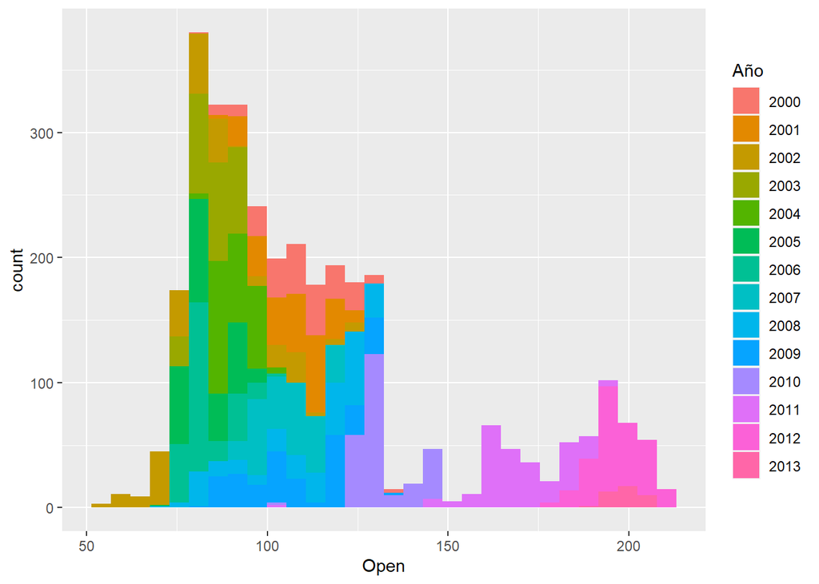

```r
# Obtén dos histogramas para las variables de precio de apertura y cierre, rellena los histogramas en función del año.

ggplot(df) +
  geom_histogram(mapping = aes(x = Open, fill = Año))
```

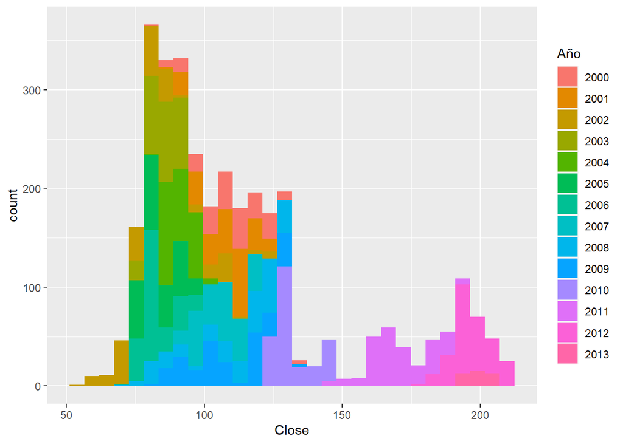

```r
ggplot(df) +
  geom_histogram(mapping = aes(x = Close, fill = Año))
```

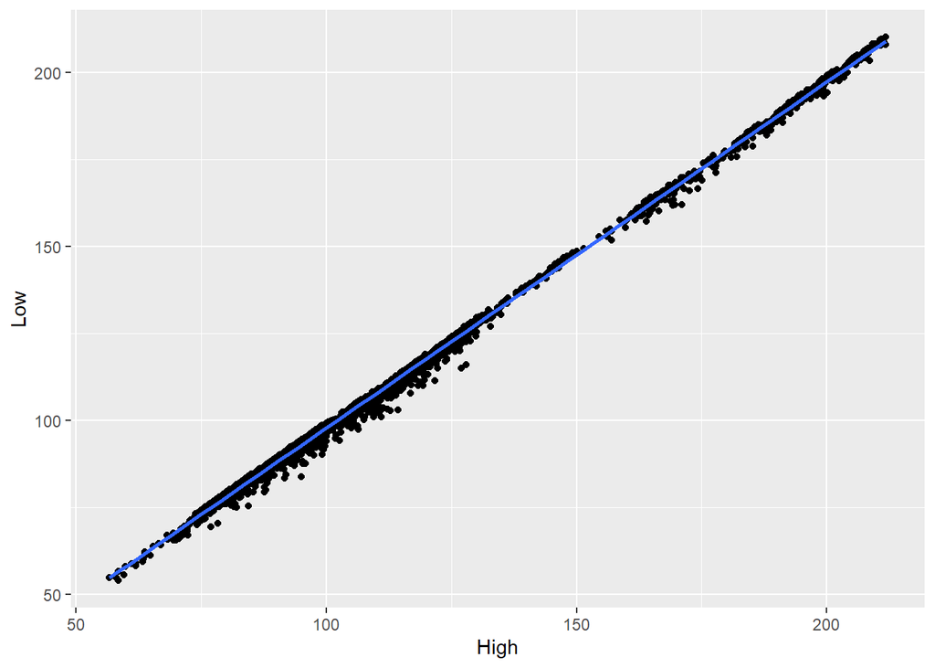

```r
# Muestra un diagrama de dispersión entre los precios más altos y más bajos, además muestra su recta de ajuste.
ggplot(df) +
  geom_point(mapping = aes(x = High, y = Low)) + geom_smooth(aes(x = High, y = Low), method = lm)
```

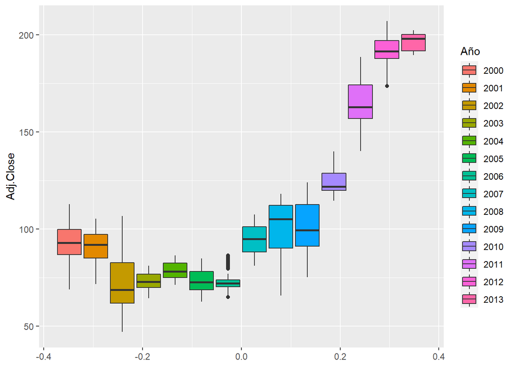

```r
# Obtén un diagrama de caja y bigotes de la variable Adj.Close por año.

ggplot(df) +
  geom_boxplot(mapping = aes(x = Adj.Close, fill = Año)) + coord_flip()
```

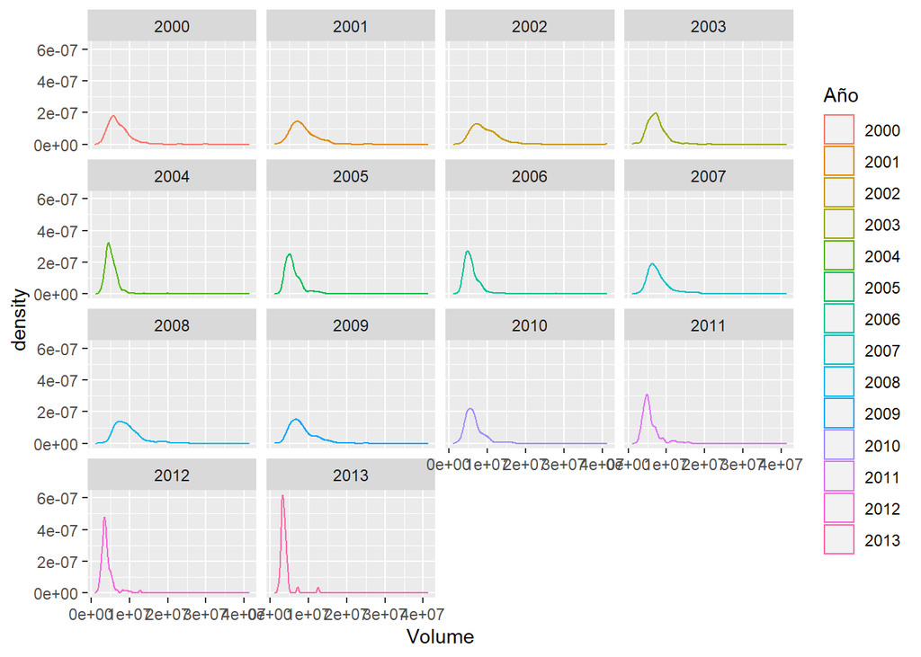

```r
# Muestra para cada año un diagrama de densidad para la variable "Volume".

ggplot(df) +
  geom_density(mapping = aes(Volume, colour = Año)) + facet_wrap(~Año)
```